# Indicadores de doença cardíaca

João Pedro Albino

10/01/2022

### Introdução

Este é um documento elaborado utilizando o pacote R Markdown. Markdown é uma sintaxe de formatação simples para a criação de documentos HTML, PDF e MS Word. Para obter mais detalhes sobre o uso de R Markdown, consulte http://rmarkdown.rstudio.com.

Quando você clica no botão ** Knit **, um documento é gerado, incluindo tanto o conteúdo quanto a saída de qualquer fragmento de código R embutido no documento.

### Sinopse

O objetivo deste documento é apresentar uma análise simples no conjunto de dados da UCI - Heart Disease Data Set, de forma a ajudar a encontrar os *três atributos mais promissores* para prever possível estreitamento no diâmetro das veias cardíacas.

Os dados utilizados estão disponíveis no UCI Machine Learning Repository (http://archive.ics.uci.edu/ml/datasets/Heart+Disease) e foram doados por:

- Instituto Húngaro de Cardiologia. Budapeste: Andras Janosi, M.D.
- Hospital Universitário, Zurique, Suíça: William Steinbrunn, M.D.
- Hospital Universitário, Basel, Suíça: Matthias Pfisterer, M.D.
- V.A. Medical Center, Long Beach e Cleveland Clinic Foundation: Robert Detrano, M.D., Ph.D.

O dataset aqui utilizado foi pré-processado pela Universidade de Cleaveland

### Baixando os dados

```r
if (!file.exists("./data/processed.cleveland.data")) {
  download.file(url = "http://archive.ics.uci.edu/ml/machine-learning-databases/heart-disease/processed.cleveland.data",
                destfile = "./data/processed.cleveland.data")
}
```

Verificando o “checksum” do arquivo armazenado localmente

```r
### Carregando o pacote necessário: tools
require(tools)
md5sum("./data/processed.cleveland.data")
```

```
##    ./data/processed.cleveland.data
## "cf81c26cdc2bac254552bf959cc3ecb2"
```

### Carregando dados no dataframe heart.data

```r
heart.data <- read.csv("./data/processed.cleveland.data", header = FALSE)
```

A página da fonte da fonte de dados original afirma que devemos ter 303 instâncias e 75 atributos.

Porém, o arquivo de dados processados pela Cleveland deve ter 14 atributos.

Vamos verificar se temos os dados de forma adequada:

```r
nrow(heart.data)
```

```
## [1] 303
```

```r
ncol(heart.data)
```

```
## [1] 14
```

```r
head(heart.data)
```

```
##   V1 V2 V3  V4  V5 V6 V7  V8 V9 V10 V11 V12 V13 V14
## 1 63  1  1 145 233  1  2 150  0 2.3   3 0.0 6.0   0
## 2 67  1  4 160 286  0  2 108  1 1.5   2 3.0 3.0   2
## 3 67  1  4 120 229  0  2 129  1 2.6   2 2.0 7.0   1
## 4 37  1  3 130 250  0  0 187  0 3.5   3 0.0 3.0   0
## 5 41  0  2 130 204  0  2 172  0 1.4   1 0.0 3.0   0
## 6 56  1  2 120 236  0  0 178  0 0.8   1 0.0 3.0   0
```

Os dados parecem corretos, então podemos prosseguir com a análise.

A descrição dos atributos do conjunto de dados na página da web são os seguintes:

1. age - age in years
2. sex - sex (1 = male; 0 = female)
3. cp - chest pain type (1 = typical angina; 2 = atypical angina; 3 = non-anginal pain; 4 = asymptomatic)
4. trestbps - resting blood pressure (in mm Hg on admission to the hospital)
5. chol - serum cholestoral in mg/dl
6. fbs - fasting blood sugar > 120 mg/dl (1 = true; 0 = false)
7. restecg - resting electrocardiographic results (0 = normal; 1 = having ST-T; 2 = hypertrophy)
8. thalach - maximum heart rate achieved
9. exang - exercise induced angina (1 = yes; 0 = no)
10. oldpeak - ST depression induced by exercise relative to rest
11. slope - the slope of the peak exercise ST segment (1 = upsloping; 2 = flat; 3 = downsloping)
12. ca - number of major vessels (0-3) colored by flourosopy
13. thal - 3 = normal; 6 = fixed defect; 7 = reversable defect
14. num - the predicted attribute - diagnosis of heart disease (angiographic disease status) (Value 0 = < 50% diameter narrowing; Value 1 = > 50% diameter narrowing)

### Preparando os dados

Para pré-processar os dados, vamos ajustar os nomes das colunas de maneira adequada:

```r
names(heart.data) <- c("age", "sex", "cp", "trestbps", "chol", "fbs", "restecg", "thalach", "exang", "oldpeak", "slope", "ca", "thal", "num")
```

Ascolunas *ca* e *thal* possuem observações com valores ausentes (missing values) indicados por “?”.

Para que possamos tratá-las adequadamente na nossa análise, iremos preenchê-las com NA (Not Available). NA é uma constante lógica de comprimento 1 que contém um indicador de valor ausente. NA pode ser forçado a qualquer outro tipo de vetor, exceto *raw*.

```r
heart.data$ca[heart.data$ca == "?"] <- NA
heart.data$thal[heart.data$thal == "?"] <- NA
```

Iremos também corrigir os tipos de algumas das variáveis, alterando-os para o tipo *fator*.

**Fator** em R é um tipo de variável usada para categorizar e armazenar os dados, tendo um número limitado de valores diferentes. Um fator armazena os dados como um vetor de valores inteiros. Fator em R também é conhecido como uma variável categórica que armazena valores de dados de string e inteiros como níveis.

```r
heart.data$sex <- factor(heart.data$sex)
levels(heart.data$sex) <- c("female", "male")
heart.data$cp <- factor(heart.data$cp)
levels(heart.data$cp) <- c("typical","atypical","non-anginal","asymptomatic")
heart.data$fbs <- factor(heart.data$fbs)
levels(heart.data$fbs) <- c("false", "true")
heart.data$restecg <- factor(heart.data$restecg)
levels(heart.data$restecg) <- c("normal","stt","hypertrophy")
heart.data$exang <- factor(heart.data$exang)
levels(heart.data$exang) <- c("no","yes")
heart.data$slope <- factor(heart.data$slope)
levels(heart.data$slope) <- c("upsloping","flat","downsloping")
heart.data$ca <- factor(heart.data$ca) # não convertendo o level porque não é necessário
heart.data$thal <- factor(heart.data$thal)
levels(heart.data$thal) <- c("normal","fixed","reversable")
heart.data$num <- factor(heart.data$num) # não convertendo o nível porque não é necessário
```

### Analisando os dados

Primeira etapa, resumindo os dados transformados:

```r
summary(heart.data)
```

```
##       age            sex                 cp         trestbps
##  Min.   :29.00   female: 97   typical     : 23   Min.   : 94.0
##  1st Qu.:48.00   male  :206   atypical    : 50   1st Qu.:120.0
##  Median :56.00                non-anginal : 86   Median :130.0
##  Mean   :54.44                asymptomatic:144   Mean   :131.7
##  3rd Qu.:61.00                                   3rd Qu.:140.0
##  Max.   :77.00                                   Max.   :200.0
##       chol          fbs             restecg       thalach      exang
##  Min.   :126.0   false:258   normal     :151   Min.   : 71.0   no :204
##  1st Qu.:211.0   true : 45   stt        :  4   1st Qu.:133.5   yes: 99
##  Median :241.0               hypertrophy:148   Median :153.0
##  Mean   :246.7                                 Mean   :149.6
##  3rd Qu.:275.0                                 3rd Qu.:166.0
##  Max.   :564.0                                 Max.   :202.0
##     oldpeak             slope        ca              thal     num
##  Min.   :0.00   upsloping  :142   0.0 :176   normal    :166   0:164
##  1st Qu.:0.00   flat       :140   1.0 : 65   fixed     : 18   1: 55
##  Median :0.80   downsloping: 21   2.0 : 38   reversable:117   2: 36
##  Mean   :1.04                     3.0 : 20   NA's      :  2   3: 35
##  3rd Qu.:1.60                     NA's:  4                    4: 13
##  Max.   :6.20
```

### Selecionado os dados

O conteúdo da variável *num* possui uma ampla faixa de valores (0 - 4). Entretanto, apenas as instâncias com “0” e “1” estão efetivamente relacionadas à possibilidade de estreitamento do diâmetro dos vasos. Portanto, iremos selecionar apenas as observações relacionados a esses dois resultados.

```r
heart.data <- heart.data[heart.data$num == "0" | heart.data$num == "1", ]
```

Verificando novamente se temos os dados de forma adequada:

```r
nrow(heart.data)
```

```
## [1] 219
```

```r
ncol(heart.data)
```

```
## [1] 14
```

```r
head(heart.data)
```

```
##   age    sex           cp trestbps chol   fbs     restecg thalach exang oldpeak
## 1  63   male      typical      145  233  true hypertrophy     150    no     2.3
## 3  67   male asymptomatic      120  229 false hypertrophy     129   yes     2.6
## 4  37   male  non-anginal      130  250 false      normal     187    no     3.5
## 5  41 female     atypical      130  204 false hypertrophy     172    no     1.4
## 6  56   male     atypical      120  236 false      normal     178    no     0.8
## 8  57 female asymptomatic      120  354 false      normal     163   yes     0.6
##         slope  ca       thal num
## 1 downsloping 0.0      fixed   0
## 3        flat 2.0 reversable   1
## 4 downsloping 0.0     normal   0
## 5   upsloping 0.0     normal   0
## 6   upsloping 0.0     normal   0
## 8   upsloping 0.0     normal   0
```

### Árvore de Decisão

**Árvores de decisão** usadas para problemas de classificação são chamadas de *Árvores de Classificação*. Nas árvores de classificação, cada nó terminal ou folha contém um rótulo que indica a classe predita para um determinado conjunto de dados. Neste tipo de árvore pode existir dois ou mais nós terminais com a mesma classe.

*Árvores de Classificação/Decisão* também podem ser definidas como uma representação de uma tabela de decisão sob a forma de árvore. Trata-se de uma forma alternativa de expressar as mesmas regras que são obtidas quando se constrói a tabela.

Para a construção da árvore, será utilizada a biblioteca *rpart*. Rpart é uma biblioteca de aprendizado de máquina em R que é usada para construir árvores de classificação e regressão. Esta biblioteca implementa particionamento recursivo.

```r
library(rpart)
```

Montando a árvore:

```r
heart.tree <- rpart(num ~ age + sex + cp + trestbps + chol + fbs + restecg +
                      thalach + exang + oldpeak + slope + ca + thal,
                    method = "class",
                    data = heart.data)
```

Plotando a árvore:

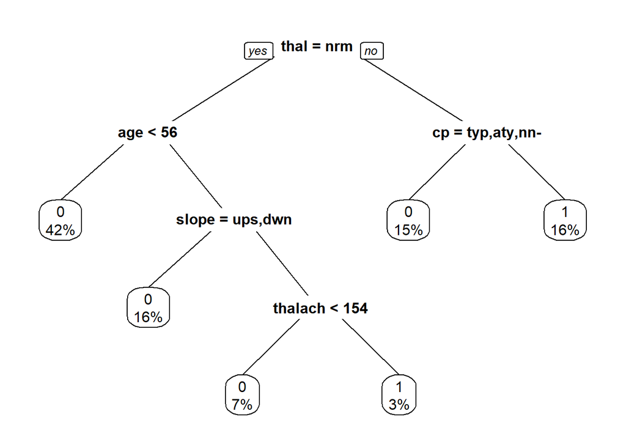

```r
library(rpart.plot)
prp(heart.tree, extra = 100)
```

### Conslusão

Baseado no gráfico da árvore, os três melhores atributos que podem prever o possível estreitamento do diâmetro são as variáveis / colunas: tal, cp e age.